# NBA Game Win Prediction Using Multivariable Regression Analysis

2025-11-06

# NBA Game Win Prediction Using Multivariable Regression Analysis

## Abstract

A multivariable logistic regression model is used to predict the binary outcome of a home team win, yielding the probability of victory. Preliminary findings indicate that these performance differentials offer strong predictive power. Specifically, differences in shooting efficiency (Field Goal and Three-Point Percentage) emerge as critical statistical variables influencing game success.

## Introduction

The purpose of this analysis is to develop predictive models that can identify which game statistics are most influential in determining the outcome of NBA games. The central research question we aim to answer is: **Which game statistics are the most significant predictors of winning an NBA game?**

This analysis may benefit several groups:

- **Sports analysts and statisticians** seeking to understand the quantitative factors that drive game outcomes
- **Team management and coaches** who can use these insights to identify areas for strategic focus and improvement
- **Sports betting analysts** interested in data-driven game predictions
- **Researchers** studying the statistical relationships in professional basketball

The goal of this project is to train predictive models using game statistics. Specifically, we aim to:

1. Build a logistic regression model to predict the binary outcome of whether the home team wins or loses
2. Identify which statistical differentials (field goal percentage, free throw percentage, three-point percentage, assists, and rebounds) are most significant in predicting game outcomes

By analyzing differential statistics rather than absolute values, we can directly compare team performance within each game and identify which performance gaps are most predictive of victory.

## Data Cleaning Steps

The data cleaning process was created through several key steps. First, the team information from “teams.csv” was integrated into the games’ data, adding abbreviations, nicknames, and cities for both home and away teams, resulting the variables: “HOME_ABBREVIATION”, “VISITOR_ABBREVIATION”, “HOME_NICKNAME”, “VISTOR_NICKNAME”, “HOME_CITY” and “VISITOR_CITY”. Next, differential variables were calculated to enable the direct comparison of team performance within each game, including “FG_diff”, “FT_diff”, “FG3_diff”, “AST_diff”, “REB_diff”, and “PTS_diff”, each representing the difference between home and away statistics. During data cleaning, the “GAME_STATUS_TEXT” column was removed as it was unnecessary for analysis, and a new variable, “ABBREVIATION_TEAM_WIN”, was created to indicate the winning team by abbreviation. Together, these steps produced a comprehensive dataset containing all original game observations enriched with team details and differential performance metrics, preparing it for further modeling and analysis.

## Visualization

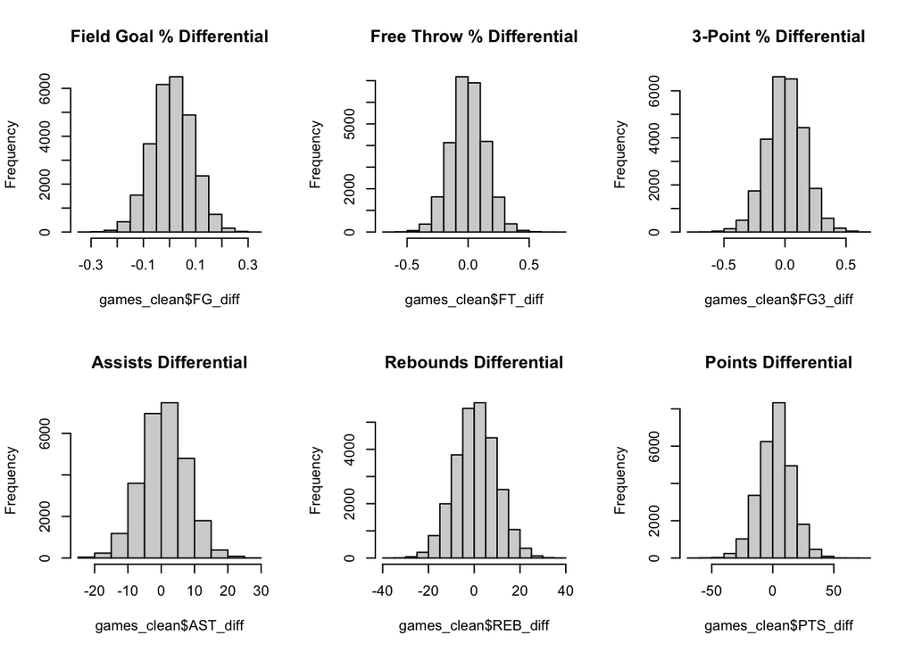

```r
  par(mfrow = c(2, 3))
  hist(games_clean$FG_diff,  main="Field Goal % Differential")
  hist(games_clean$FT_diff,  main="Free Throw % Differential")
  hist(games_clean$FG3_diff, main="3-Point % Differential")
  hist(games_clean$AST_diff, main="Assists Differential")
  hist(games_clean$REB_diff, main="Rebounds Differential")
  hist(games_clean$PTS_diff, main="Points Differential")
```

The histograms above display the distributions of each performance differential variable used in the analysis. All six differentials are centered close to zero, which is expected because they represent the home team’s performance minus the away team’s performance. Each variable shows a roughly symmetric, bell-shaped distribution, indicating that home teams do not consistently outperform away teams in any single metric across all games.

Field goal (FG%), free throw (FT%), and three-point percentage (3PT%) differentials exhibit relatively tight spreads, reflecting that shooting efficiency differences between teams tend to be modest. In contrast, assists and rebounds display wider variability, suggesting larger game-to-game fluctuations in these counting statistics. Point differential has the broadest spread, which aligns with variation in final game outcomes.

These histograms confirm that the predictors behave like continuous, well-distributed performance metrics without extreme skewness or heavy outliers. This supports the suitability of using these variables in a logistic regression framework to predict game outcomes.

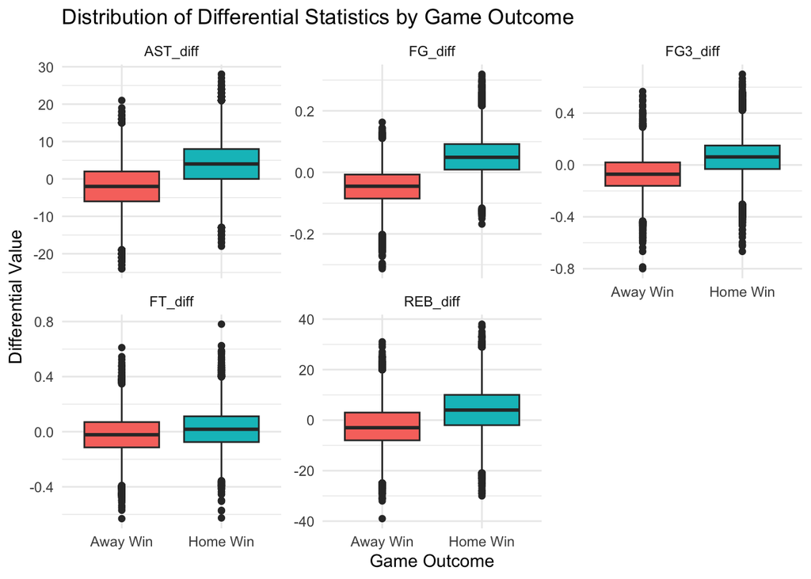

```r
boxplot_diff
```

These visualizations give supple initial evidence that the selected predictors differ between wins and losses. This justifies their usage in the logistic regression model,

The scatter plots below represent relationships between point differential and the differential of five statistics. Comparing these is a good way to analyze the impact that each of the statistics can have on the outcome of a game. Every statistic, including point differential, is measured by the home teams number minus the away teams number. This way, everything is consistent. All of the plots have an upward facing slope, which fits with our intuitive expectations. Winning a differential of any of these statistics helps with winning and overall point differential. However, some have a much stronger impact on the outcome of the game than others.

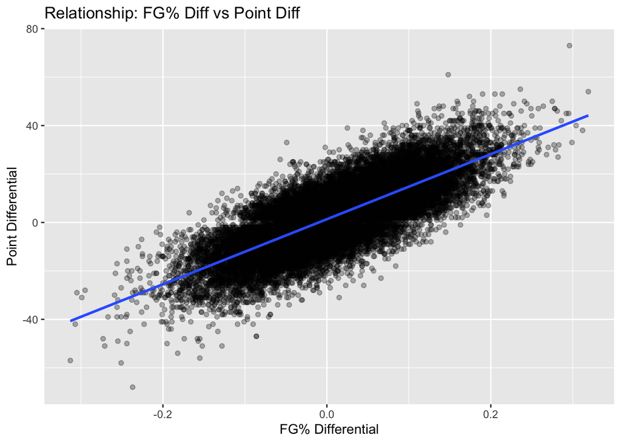

```r
FG_scat
```

The FG% differential plot has the steepest slope among all metrics analyzed. When a team has a higher percentage of shots made, they will be more likely to win because they will be scoring more of their shot attempts. The larger the differential, the larger the point differential will be assuming that both teams take the same number of shots. It is important to note that winning the field goal % differential does not guarantee winning the game, as outside factors like turnovers and number of shots taken can affect winning in separate ways.

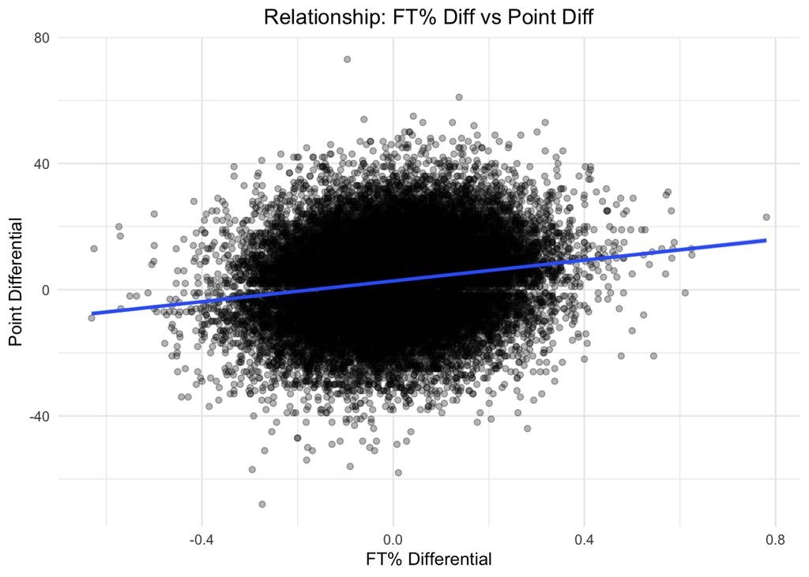

```r
FT_scat
```

The FT% differential plot is far less steep than the FG% differential plot, likely due to free throws not being a very large percentage of overall scoring. Additionally, the amount of total free throws attempts can be very different with certain teams due to style of play, officiating, and luck.

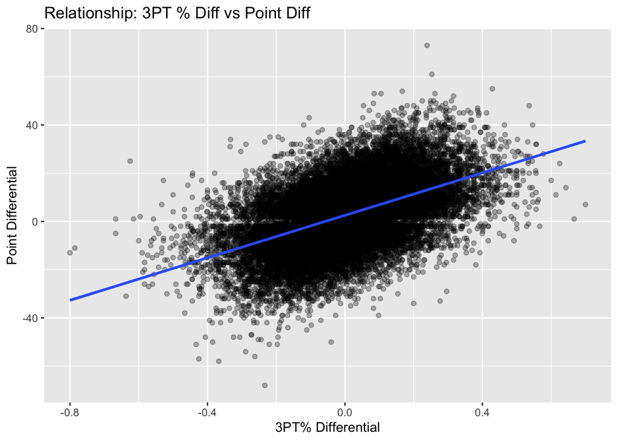

```r
FG3_scat
```

The 3PT% differential plot follows a similar pattern to the field goal percentage graph, although it is not as steep. The 3PT% differential serves as a middle ground between FT% and FG%. Three pointers intuitively have a larger effect on the outcome of a game than free throws because of their intrinsic higher value (3 points > 1 point) and the increasing number of 3 point shots taken in the modern NBA. 3PT% has a similar situation where the attempts can fluctuate, meaning that it is possible to have a negative point differential despite having a higher 3PT%.

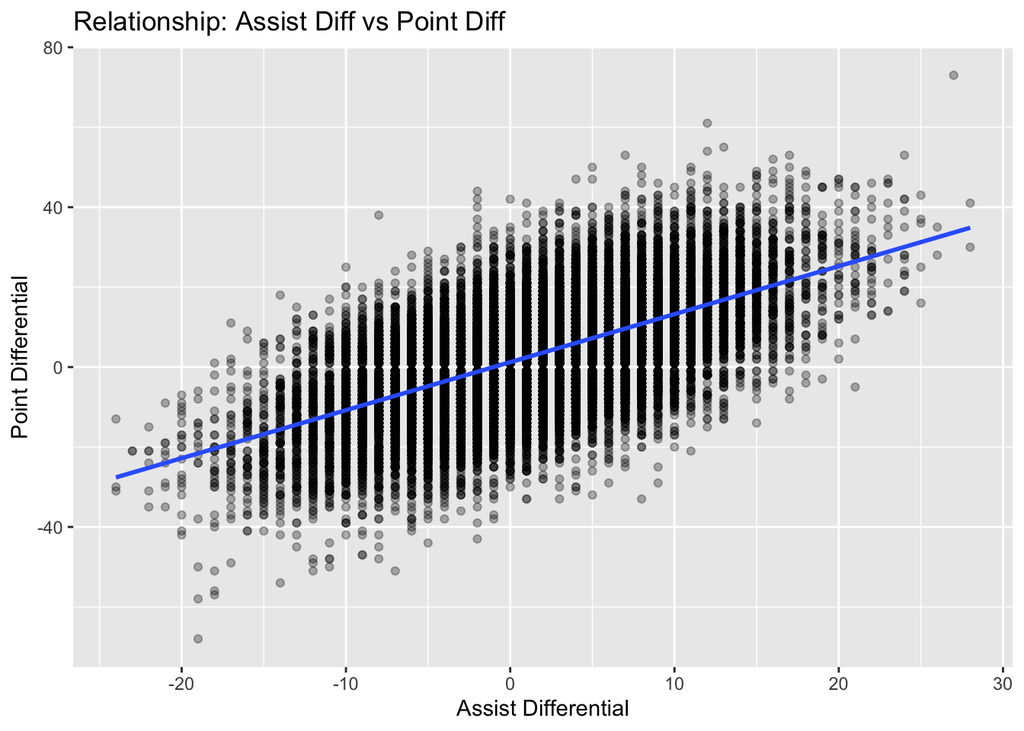

```r
AST_scat
```

The assist differential plot exhibits a distinct shape compared to percentage-based metrics because assists are recorded as discrete counts rather than proportions. Since an assist is credited only when a pass directly leads to a made basket, higher assist totals generally correspond to more efficient offensive execution and, consequently, larger point differentials. Although not every scoring possession results from an assist, assist differential remains a meaningful performance indicator and shows a strong association with game outcomes.

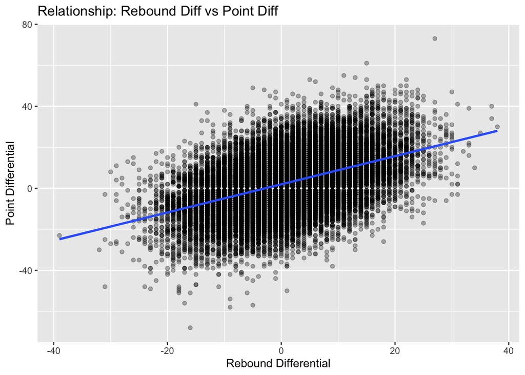

```r
REB_scat
```

Similar to assists, rebounds are recorded as whole numbers, which contributes to the cleaner appearance of the rebound differential plot compared to percentage-based metrics. Rebounds are positively correlated with winning, though the relationship is weaker than that of assists. This is reasonable because rebounds do not directly generate points. Offensive rebounds can lead to second-chance scoring opportunities, but the majority of rebounds in a game are defensive. While defensive rebounds do not add to a team’s score, securing them prevents the opponent from extending possessions, reflects missed opponent shots, and increases the number of possessions for a team, all of which contribute indirectly to a stronger point differential.

## Analysis

```r
win_model_summary <- tidy(win_model)
win_model_summary
```

```
## # A tibble: 6 × 5
##   term        estimate std.error statistic   p.value
##   <chr>          <dbl>     <dbl>     <dbl>     <dbl>
## 1 (Intercept)   0.269    0.0189       14.2 7.33e- 46
## 2 FG_diff      25.4      0.421        60.2 0
## 3 FT_diff       4.18     0.140        29.7 2.13e-194
## 4 FG3_diff      4.59     0.145        31.8 1.62e-221
## 5 AST_diff      0.0766   0.00356      21.5 1.94e-102
## 6 REB_diff      0.0914   0.00241      37.9 0
```

The logistic regression model (win_model) evaluates how differential performance metrics influence the probability of a home team winning. Below is a detailed interpretation of each predictor:

After fitting the logistic regression model, we generated predicted win probabilities for each game. For each observation, the model outputs the probability that the home team wins based on the statistical differentials. We then classify each game as a predicted home win or predicted away win using a 0.5 probability cutoff. Finally, we label the prediction as “HOME” or “AWAY” to summarize the model’s expected winner.

```r
flextable(pred_table) %>%
  set_caption("Sample of Model Predictions for Game Outcomes") %>%
  autofit()
```

Sample of Model Predictions for Game Outcomes

| Home_Team | Away_Team | Actual_Winner | Predicted_Winner | Predicted_Prob | Correct | Predicted_Side |
| --- | --- | --- | --- | --- | --- | --- |
| Pelicans | Spurs | Pelicans | Pelicans | 0.818 | true | HOME |
| Jazz | Wizards | Jazz | Wizards | 0.435 | false | AWAY |
| Cavaliers | Bucks | Cavaliers | Bucks | 0.447 | false | AWAY |
| 76ers | Pistons | 76ers | 76ers | 0.973 | true | HOME |
| Hawks | Bulls | Bulls | Bulls | 0.491 | true | AWAY |
| Celtics | Pacers | Pacers | Pacers | 0.279 | true | AWAY |

## Conclusion

Assists and rebounds also contributed to win probability, though their effects were comparatively much smaller. This suggests that while ball movement and rebounding support overall team success, they are less decisive than shooting efficiency in predicting outcomes in the modern NBA. Assists were the weakest contributing factor in our model in predicting outcomes which we believe is a direct reflection of the NBA moving away from team play.

The direction and magnitude of each coefficient aligned with expectations: teams that shoot better, pass better, and secure extra possessions via rebounds tend to outperform their opponents.

Overall, our logistic regression model successfully captured the relationship between winning NBA games and performance differentials. Although logistic regression provided strong baseline predictive insight, future improvements can include exploring non-linear models, incorporating player-level metrics, or account for variables such as rest days, travel distance, or injuries. Expanding the feature set would likely improve predictive accuracy and provide a more comprehensive understanding of the factors that drive NBA game results.